# 09.Serial Peripheral Interface

Modified

Tu 2023-03-14 15:56

Serial Peripheral Interface (SPI) is a synchronous serial communication interface. It is prevalent in various devices we use every day. The Arduino is capable of using this interface to communicate with various devices. SD cards (and microSD cards) use SPI to interface with their host. The SPI bus is similar to the Serial line that we have used previously to communicate with the Arduino in that it is a data bus. That is, it transmits or transfers data. The SPI bus, however, accomplishes this data transfer differently than the Serial lines. Instead of a transmit line (TX line) and receive line (RX line) as with the Serial bus, the SPI bus uses four different lines. It uses a serial clock line (PIN 13), a data in line (PIN 12), a data out line (PIN 11), and a slave select line (PIN 8, but this one could change depending on what is being connected to the Arduino). The serial clock line is typically abbreviated as SCLK and is used to specify the timing of the data being transmitted and received.

With the Serial lines we previously have used, the data’s timing had to be agreed upon by both devices (i.e., the Arduino and computer). If you recall, we did this by setting the baud rate on both the Arduino and the computer. However, the SPI baud rate does not have to be agreed upon before communication because a dedicated line sets the communication speed. The data out line and data in line (PIN 11 and 12) are known as “Master Out/Slave In” (MOSI) and “Master In/Slave Out” (MISO), respectively. The terminology used in SPI is in terms of master and slaves. In our case, the master is the Arduino, and the slave is the microSD card. The MOSI sends out data from the master (i.e., the Arduino), and it goes into the slave (i.e., the microSD card). With the MISO line, the slave sends out data, and it goes into the master. A diagram of the connections is shown below in Figure 1.

Figure 1: SPI Configuration

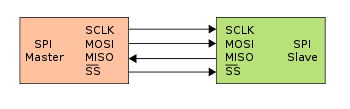

With SPI, you may have multiple slaves. The way that the master tells the slaves who it is talking to is done by the last line, the slave select (SS) line. The slave select line (PIN 8) tells the various slaves which one must receive the master’s message. There is a separate SS line for each slave connected to the master in the most common SPI arrangement. A multiple slave SPI configuration is shown in Figure 2.

Figure 2: Multi slave SPI configuration

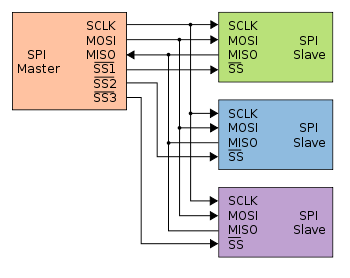

For further reading about SPI, Sparkfun has a good tutorial on the basics found [here](https://learn.sparkfun.com/tutorials/serial-peripheral-interface-spi).